# Practice 5.1 plz work

Annie

2024-11-01

```r
library(rgbif)
```

⚠ Practice 5.1 Using the rgbif package download data from any species you like. Make a nice map of the distribution of the selected species. Of course you will fix projection problem when plotting you map. You map can be static or interactive.

```r
library(rgbif)
library(ggplot2)
library(leaflet)
library(maps)
```

#occ_search 是用於搜索物種出現記錄的函數 #hasCoordinate=T 表示只選擇具有坐標訊息的記錄 #limit=1000 限制下載的記錄數量為 1000 條

```r
species_name <- "Setonix brachyurus"
occ_data <- occ_search(scientificName = species_name, limit = 1000, hasCoordinate = TRUE)
occ_df <- occ_data$data
```

Check CRS1

```r
print(occ_df)
```

```
## # A tibble: 1,000 × 154
##    key        scientificName  decimalLatitude decimalLongitude issues datasetKey
##    <chr>      <chr>                     <dbl>            <dbl> <chr>  <chr>
##  1 4510348026 Setonix brachy…           -32.0             115. cdc,c… 50c9509d-…
##  2 4510427525 Setonix brachy…           -32.0             115. cdc,c… 50c9509d-…
##  3 4512355808 Setonix brachy…           -31.9             116. cdrou… 50c9509d-…
##  4 4516526477 Setonix brachy…           -34.9             118. cdc,c… 50c9509d-…
##  5 4516527830 Setonix brachy…           -31.9             116. cdc,c… 50c9509d-…
##  6 4516272879 Setonix brachy…           -31.8             116. cdrou… 50c9509d-…
##  7 4516614049 Setonix brachy…           -32.0             115. cdc,c… 50c9509d-…
##  8 4516188081 Setonix brachy…           -31.8             116. cdrou… 50c9509d-…
##  9 4516541140 Setonix brachy…           -31.9             115. cdrou… 50c9509d-…
## 10 4516188082 Setonix brachy…           -31.8             115. cdrou… 50c9509d-…
## # ℹ 990 more rows
## # ℹ 148 more variables: publishingOrgKey <chr>, installationKey <chr>,
## #   hostingOrganizationKey <chr>, publishingCountry <chr>, protocol <chr>,
## #   lastCrawled <chr>, lastParsed <chr>, crawlId <int>, basisOfRecord <chr>,
## #   occurrenceStatus <chr>, taxonKey <int>, kingdomKey <int>, phylumKey <int>,
## #   classKey <int>, orderKey <int>, familyKey <int>, genusKey <int>,
## #   speciesKey <int>, acceptedTaxonKey <int>, acceptedScientificName <chr>, …
```

Basic static map #geom_polygon() 用於創建填充的多邊形，表示世界地圖 #group = group：告訴 ggplot2 如何將數據分組以形成多邊形的邊界。在這裡，group 是資料框中的一個變量，用於識別哪些點應該被視為同一個多邊形的部分。這意味著如果有多個多邊形（例如，國家或省的形狀），group 會確保這些點被正確地連接在一起以形成各自的形狀。 #alpha:透明度

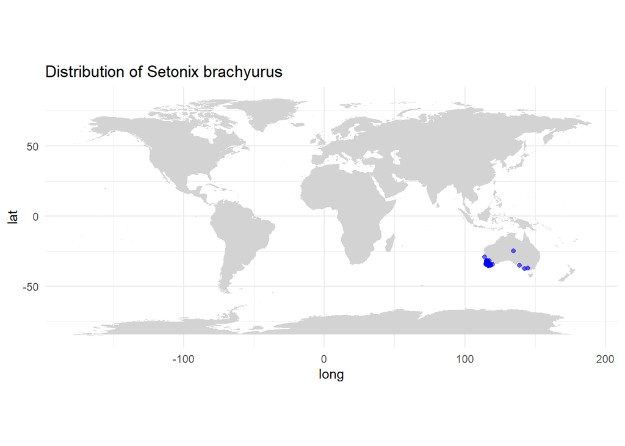

```r
world <- map_data("world") #載入世界地圖數據
ggplot() +
  geom_polygon(data = world, aes(x = long, y = lat, group = group), fill = "lightgray") +#世界地圖
  geom_point(data = occ_df, aes(x = decimalLongitude, y = decimalLatitude), color = "blue", alpha = 0.6) +#加物種點點
  coord_fixed() +#確保 x 軸的每個單位等於 y 軸的每個單位，維持地圖的正確比例
  labs(title = paste("Distribution of", species_name)) +
  theme_minimal()
```

#~decimalLongitude 和 ~decimalLatitude : 指定經度和緯度的映射 #fillOpacity = 0.6 : 標記的填充透明度為0.6

```r
leaflet(occ_df) %>%
  addTiles() %>% #加入世界地圖
  addCircleMarkers(~decimalLongitude, ~decimalLatitude, radius = 3, color = "blue", stroke = FALSE, fillOpacity = 0.6) %>%
  addLegend("topright", colors = "blue", labels = species_name, title = "Species Distribution")
```

[interactive chart not shown]

Quokkaaaaa ahhhhh好煩一直按到放大縮小

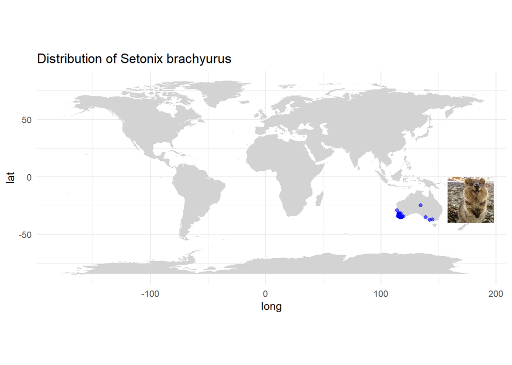

```r
library(ggplot2)
library(ggimage)
library(jpeg)
library(grid)


potato_path <- "C:/Users/User/Desktop/碩一上/RRRRR/0924-in-class-practice/quok.jpg"
chips <- readJPEG(potato_path)


ggplot() +
  geom_polygon(data = world, aes(x = long, y = lat, group = group), fill = "lightgray") +  # wrld map
  geom_point(data = occ_df, aes(x = decimalLongitude, y = decimalLatitude), color = "blue", alpha = 0.6) +
  coord_fixed() +  ##確保 x 軸的每個單位等於 y 軸的每個單位，維持地圖的正確比例
  labs(title = paste("Distribution of", species_name)) +
  theme_minimal() +
  # Quokka pic
  annotation_custom(rasterGrob(chips),
                    xmin = max(occ_df$decimalLongitude) + 1,
                    xmax = max(occ_df$decimalLongitude) + 65,
                    ymin = max(occ_df$decimalLatitude) - 15,
                    ymax = max(occ_df$decimalLatitude) + 25)
```

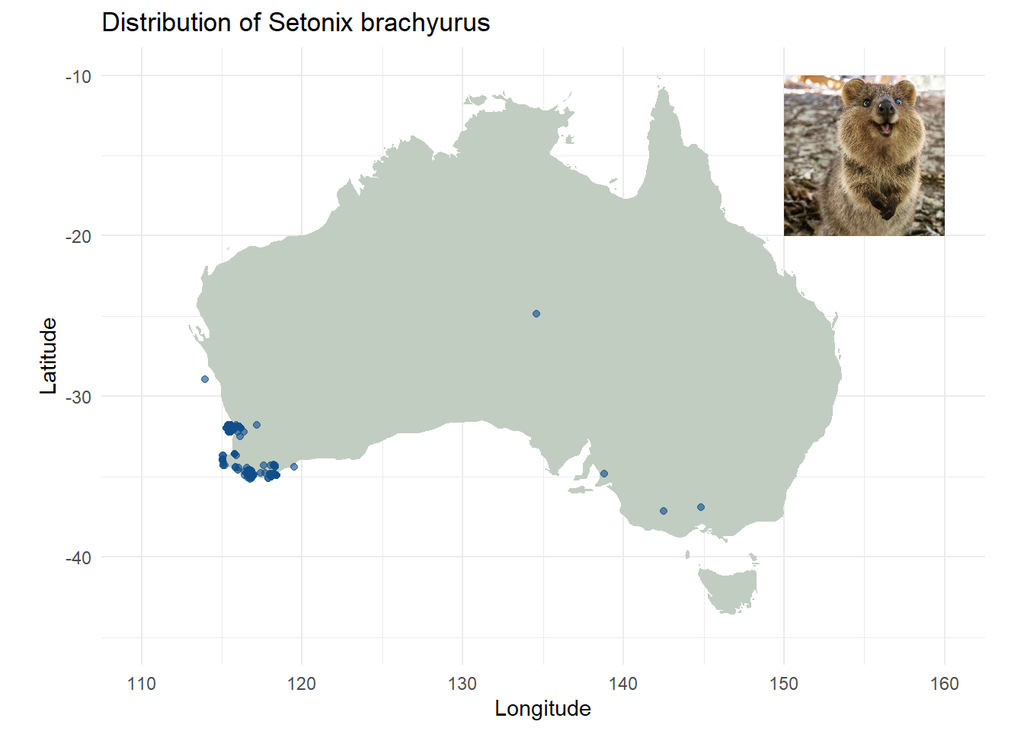

```r
library(ggplot2)
library(ggimage)
library(jpeg)
library(grid)
library(maps)


world <- map_data("world")

hotdog <- subset(world, region == "Australia")


potato_path <- "C:/Users/User/Desktop/碩一上/RRRRR/0924-in-class-practice/quok.jpg"
chips <- readJPEG(potato_path)

ggplot() +
  geom_polygon(data = hotdog, aes(x = long, y = lat, group = group), fill = "#C1CDC1") +  # Australia map
  geom_point(data = occ_df, aes(x = decimalLongitude, y = decimalLatitude), color = "#104E8B", alpha = 0.6) +  # Species points
  coord_fixed(xlim = c(110, 160), ylim = c(-45, -10)) +  # Focus on Australia
  labs(title = paste("Distribution of", species_name),
       x = "Longitude",
       y = "Latitude") +
  theme_minimal() +
  annotation_custom(rasterGrob(chips),
                    xmin = 150,
                    xmax = 160,  # longtitude position
                    ymin = -10,
                    ymax = -20)  # latitude position
```

```r
ggsave(filename = "Cocoa.pdf")
```